# **Modelo Predictivo para entidades que contratan servicios de Call Center con terceros basado en datos de Normas Estandar COPC**

Adrian Felipe Pinzon Hurtado (apinzonh)

[figure not shown]

# 1 **Repositorio**

https://github.com/adrife20/PEC3_TFM_adpinzon

# 2 **Presentación y problemática (desafío)**

La gran mayoría de las empresas contratan los servicio de call center con un externo (proveedor). Actualmente, con el auge de los bots, muchos de estos proveedores ofrecen un paquete que incluye atención de agentes humanos y bots. Estos nuevos paquetes de facturación se ofrecen en rangos de contactos mensuales llamados líneas bases, los cuales tienen un precio dependiendo del rango que estés dispuesto a pagar y tambien los promedio de contactos que recibes mensualmente.

La mayoría de las empresas necesitan un modelo estadístico que les pueda dar ese precio ideal teniendo en cuenta los datos con los que cuentan, que es el costo actual de su call center, los indicadores COPC y lo que está atendiéndose por bots. En la mayoría de estos contratos, las empresas contratan el servicio sin tener en cuenta número de asesores humanos, como sí lo hace el proveedor, quien tiene para eso modelos muy maduros en el mercado como Erlang o ARIMA. Esto debido que la administración de ese personal no es core de las empresas, más sí de los call center.

El dataset cuenta con un histórico de estas facturaciones mensuales por call center, junto con todos los indicadores COPC, eventos masivos, número de contactos por bots, casos por masivos y disponibilidad de los canales. El proveedor contractualmente jamás revela su número de asesores, porque es una estrategia de ahorro de costos que utilizan. Por ejemplo, pueden poner un asesor para que conteste hasta tres chats simultáneos o una llamada y una chat simultáneo, ya que este último canal tiene un mayor ASA, es decir, el usuario puede esperar un poco más a que le contesten (en esta data, está convenido hasta 60 segundos para contestar por chat).

El reto es poder predecir una nueva tabla de precios ideales para negociar un RFP (Request for Proposals) o solicitud de propuestas, o desde una administración entender si lo que se está pagando está muy por encima de lo que debería ser.

# 3 **Descripción del Dataset**

Se relacionan a continuación la descripción de cada variable:

TABLA RESUMEN VARIABLES DATA ‘TEST’

[output not shown]

() Corresponden a norma COPC. (**) Corresponde a metodología ITIL.

# 4 **Limpieza y preprocesamiento de datos**

| ID | Mesa | Fecha | Contactos_Atendidos_telefono | Contactos_Atendidos_Chat | Contactos_Atendidos_Chatbot | Contactos_autoreporte_gestion_indirecta | Contactos_ofrecidos | Contestados_Chat_men_Umbral | Contestado_Tel_men_Umbral | SD06_ASA_Correo | SD05_Disponibilidad_de_la_mesa_de_servicio | gestion_autoreporte | No_masivos | Linea_Base | AHT_Tel_seg | AHT_chat_seg | Costo |
| --- | --- | --- | --- | --- | --- | --- | --- | --- | --- | --- | --- | --- | --- | --- | --- | --- | --- |
| 1 | Tecnologia | 2016-08 | 45739 | 15013 | 2618 | 4295 | 79066 | 9667 | 34158 | 11.79 | 0.9998 | 13.00 | 1740 | 64308 | 725 | 975 | NA |
| 2 | Tecnologia | 2016-09 | 49778 | 13613 | 2429 | 3066 | 77648 | 10941 | 43036 | 14.00 | 0.9998 | 9.49 | 1647 | 64801 | 670 | 926 | NA |
| 3 | Tecnologia | 2016-10 | 45791 | 12776 | 1760 | 2624 | 66346 | 10161 | 37465 | 27.13 | 0.9991 | 11.09 | 1127 | 61110 | 660 | 930 | NA |
| 4 | Tecnologia | 2016-11 | 48796 | 15540 | 2208 | 2366 | 86326 | 7601 | 23921 | 10.32 | 0.9996 | 12.58 | 4768 | 62755 | 688 | 961 | NA |
| 5 | Tecnologia | 2016-12 | 44182 | 12541 | 1874 | 2394 | 63829 | 10175 | 37350 | 9.59 | 0.9904 | 12.21 | 1150 | 56338 | 643 | 949 | NA |
| 6 | Tecnologia | 2017-01 | 50021 | 15315 | 1873 | 2618 | 77217 | 10411 | 35900 | 12.90 | 1.0000 | 7.81 | 3340 | 63017 | 680 | 948 | NA |
| 7 | Tecnologia | 2017-02 | 47534 | 13635 | 1295 | 2946 | 72188 | 9147 | 31894 | 10.85 | 0.9999 | 13.42 | 2457 | 59123 | 680 | 952 | NA |
| 8 | Tecnologia | 2017-03 | 50579 | 15403 | 1751 | 3325 | 75397 | 12349 | 42037 | 9.62 | 1.0000 | 11.32 | 2307 | 63653 | 626 | 826 | NA |
| 9 | Tecnologia | 2017-04 | 46743 | 13670 | 1304 | 2835 | 74187 | 8456 | 29248 | 13.73 | 0.9996 | 14.73 | 1477 | 56530 | 617 | 867 | NA |
| 10 | Tecnologia | 2017-05 | 56268 | 17046 | 1608 | 3570 | 91969 | 8822 | 27980 | 11.01 | 1.0000 | 13.23 | 4380 | 71498 | 600 | 890 | NA |

* Muestra de variables tomadas en cuenta para el modelo

## 4.1 Valores perdidos

Se toma el argumento de KNN con la habilitación del parámetro numFun = median. Se realiza con k=5.

Variables con datos nulos:

SD06_ASA_Correo gestion_autoreporte

Para estos valores perdidos (NA) se recorre en el daframe con las nuevas variables BPD_Imputada y AD_imputada, las cuales se muentras como TRUE o FALSE, que significa que fueron o no imputadas por el algoritmo de Gower.

Se contaban con un contrato desde 2016 hasta agosto de 2019, donde inicia un nuevo RFP. Por lo tanto, no se deben tomar precios de antes de esta fecha, eran incoherentes porque el contrato anterior tenía otras condiciones, y no habían variables en el precio como IPC u otras indicativas de aumento gradual.

No se identifican por los índices cuáles eran los valores perdidos (NA) , sólo se harán para los precios antes de agosto de 2019, se recorren en la base con las nuevas variables Costo_Imputada, las cuales se muestran como TRUE o FALSE, que significa que fueron o no imputadas por el algoritmo de Gower.

## 4.2 Valores extremos

Se analiza la presencia de posibles valores extremos (outliers) en las distintas variables:

- Contactos_Atendidos_telefono,
- Contactos_Atendidos_Chat,
- Contactos_Atendidos_Chatbot,
- Contactos_autoreporte_gestion_indirecta,
- Contactos_ofrecidos, Contestados_Chat_men_Umbral, Contestado_Tel_men_Umbral,
- SD06_ASA_Correo,
- SD05_Disponibilidad_de_la_mesa_de_servicio,
- ASA_gestion_autoreporte,
- No_masivos,
- Linea_Base,
- AHT_Tel_seg,
- AHT_chat_seg
- Costo

  Se tienene valores nulos para los registros antes de agosto de 2019, que era otro RFP

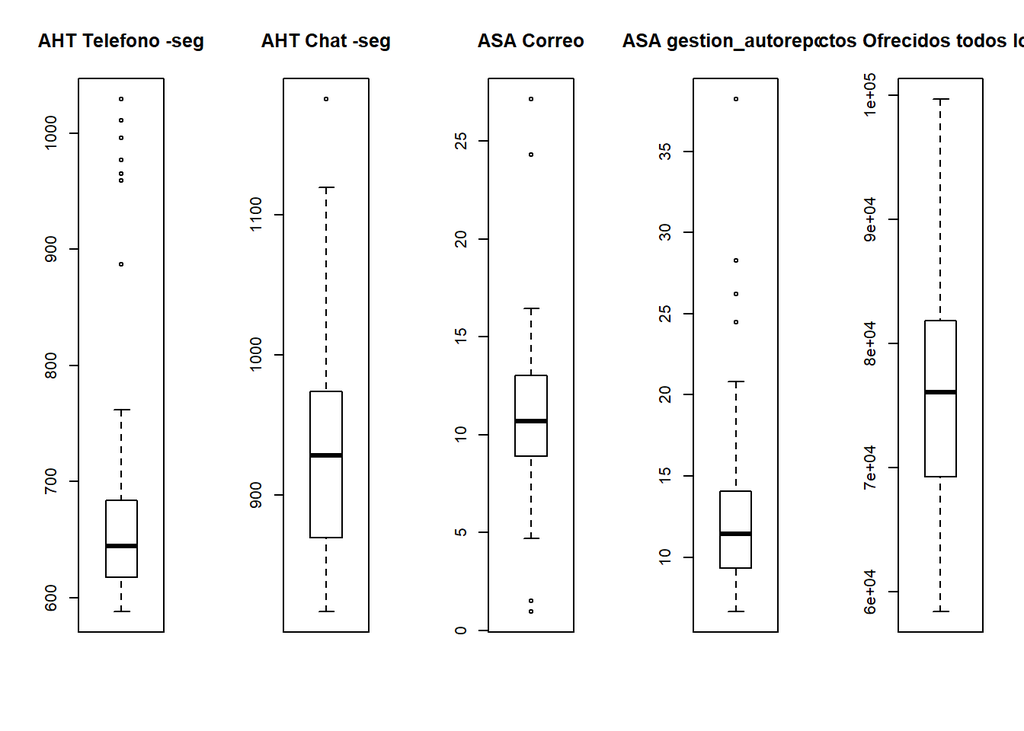

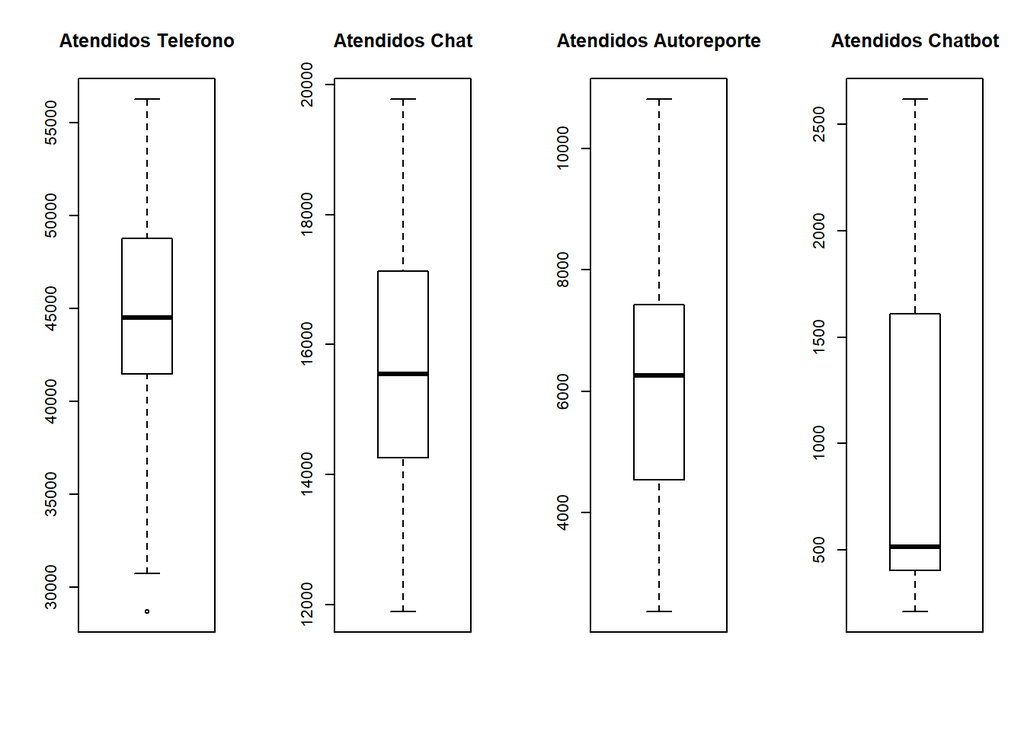

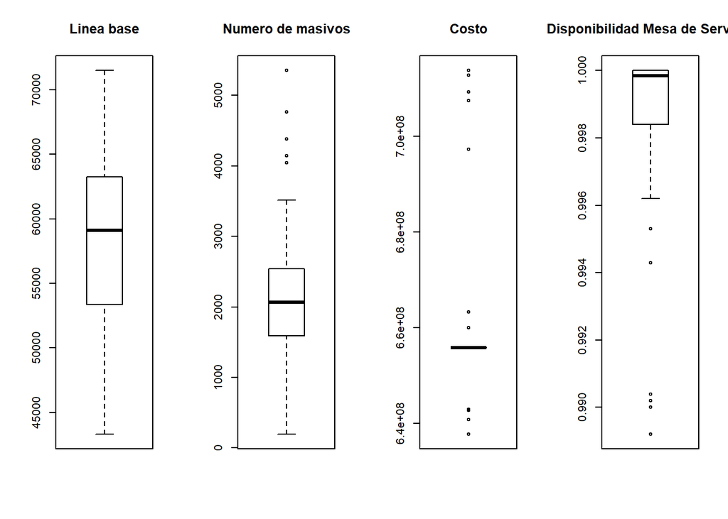

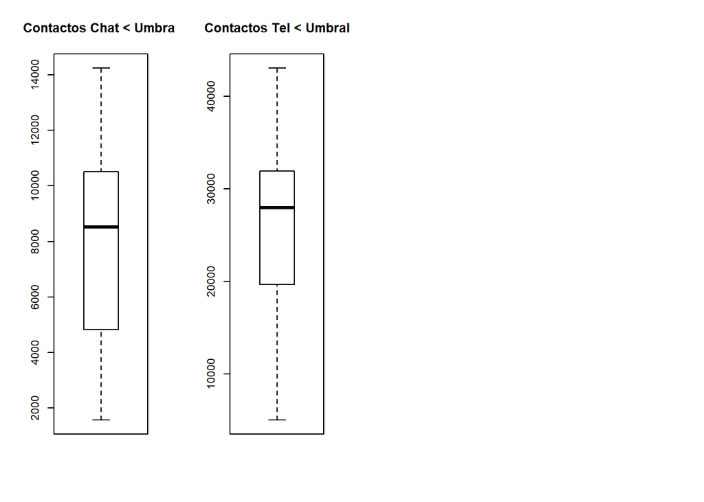

Se observa que para el AHT Chat, todos los outliers están en Operaciones y en los últimos meses, por lo que se borran estos datos. El único AHT Chat fuera de lo común en Tecnologia, fue del mes de abril-2020, con 1182 seg (19,7 min).

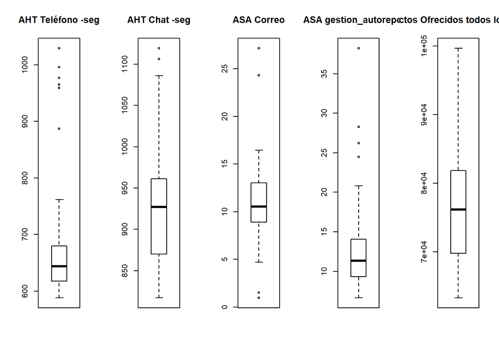

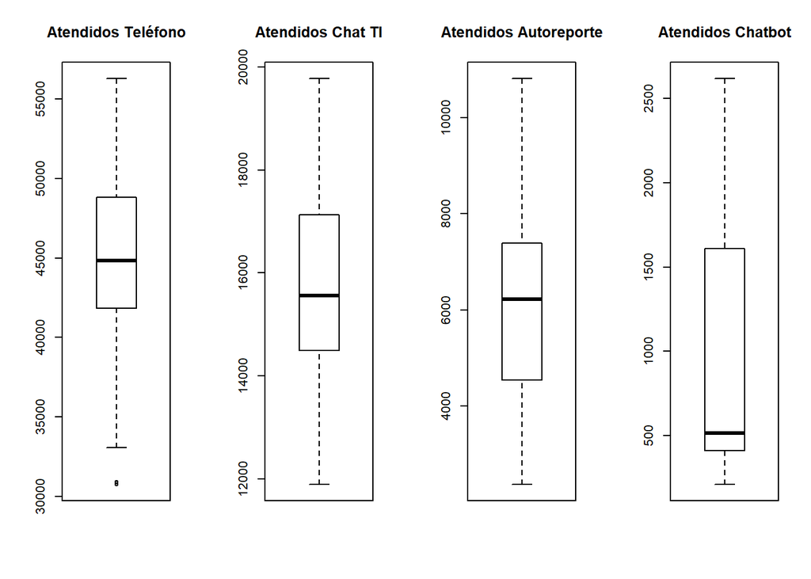

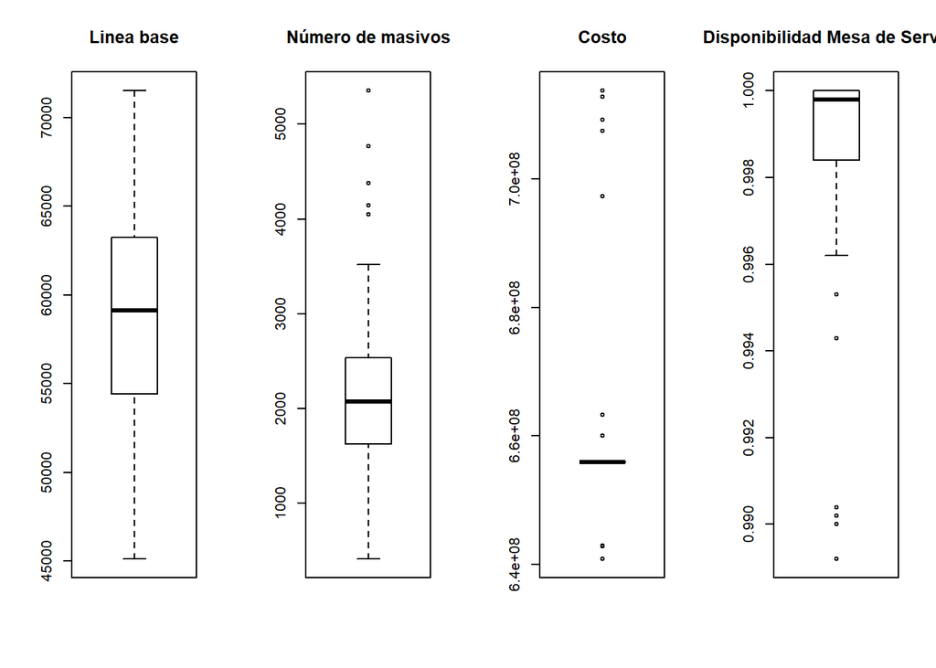

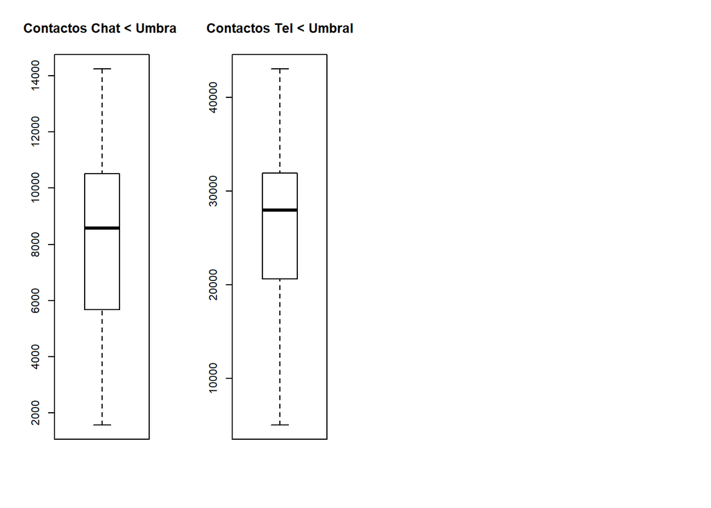

```r
#masivos:
values_masivos <- df2.1$Linea_Base
values_masivos <-boxplot.stats(values_masivos)$out
idxm <- which(df2.1$Linea_Base %in% values_masivos)
#idx
mas_outliers <- df2.1[idxm,]
#mas_outliers
#rows.masborrar <- c()#quitar costo cuando se tenga data
#cols.borrar <- c("Fecha","AHT_Tel_min","AHT_Chat_min")

df2.2 <- c()

df2.2 <- data.frame(df2.1)

#df <- df[, ! names(df) %in% cols.SQLborrar, drop = F]
#df2.2 <- df2.1[! (df2.1$ID %in% rows.masborrar),]
#df2.2
```

[figure not shown]

```r
par(mfrow=c(1,5))
boxplot(dfNA$AHT_Tel_seg, main="AHT Teléfono -seg" )
boxplot(dfNA$AHT_chat_seg, main="AHT Chat -seg" )
boxplot(dfNA$SD06_ASA_Correo, main="ASA Correo" )
boxplot(dfNA$gestion_autoreporte, main="ASA gestion_autoreporte" )
boxplot(dfNA$Contactos_ofrecidos, main="Contactos Ofrecidos" )
```

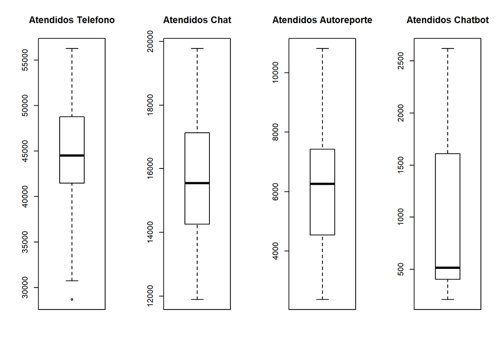

```r
par(mfrow=c(1,4))
boxplot(dfNA$Contactos_Atendidos_telefono, main="Atendidos Telefono" )
boxplot(dfNA$Contactos_Atendidos_Chat, main="Atendidos Chat" )
boxplot(dfNA$Contactos_autoreporte_gestion_indirecta, main="Atendidos Autoreporte" )
boxplot(dfNA$Contactos_Atendidos_Chatbot, main="Atendidos Chatbot" )
```

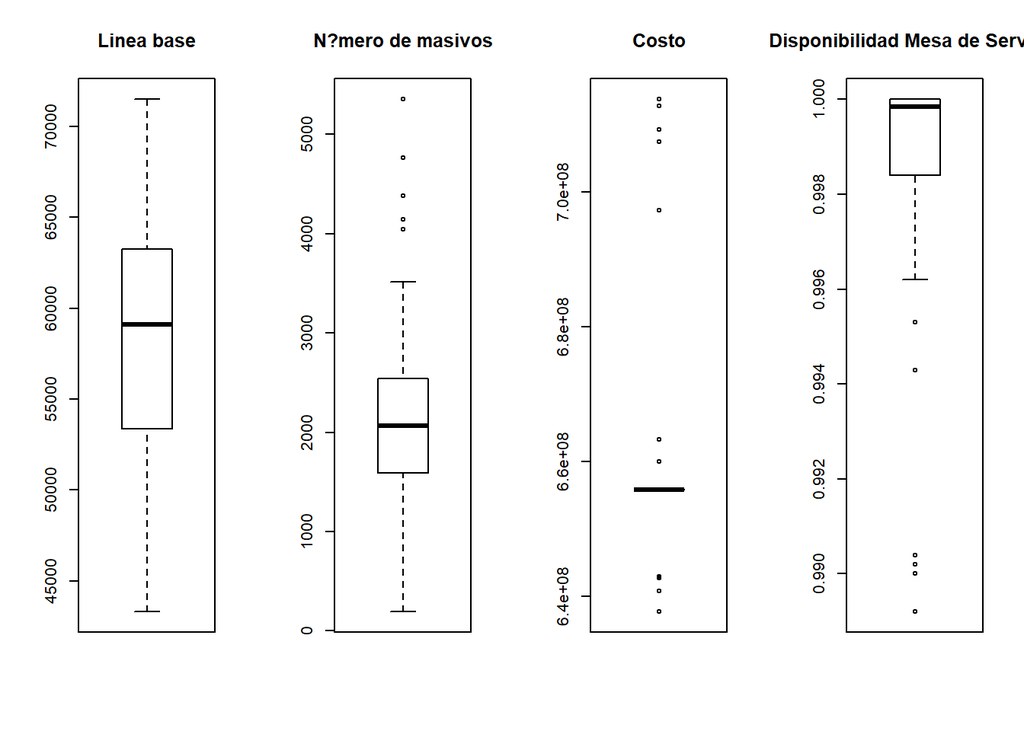

```r
par(mfrow=c(1,4))
boxplot(dfNA$Linea_Base, main="Linea base" )
boxplot(dfNA$No_masivos, main="N?mero de masivos" )
boxplot(dfNA$Costo, main="Costo" )
boxplot(dfNA$SD05_Disponibilidad_de_la_mesa_de_servicio, main="Disponibilidad Mesa de Servicio" )
```

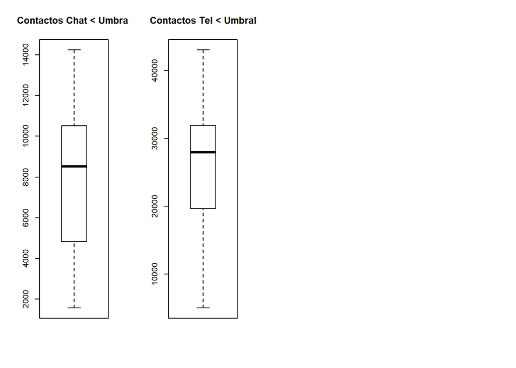

```r
par(mfrow=c(1,4))
boxplot(dfNA$Contestados_Chat_men_Umbral, main="Contactos Chat < Umbral" )
boxplot(dfNA$Contestado_Tel_men_Umbral, main="Contactos Tel < Umbral" )
```

### 4.2.1 Correlaciones

Nos proponemos analizar las relaciones entre las diferentes variables del conjunto de datos para ver cómo es esta correlación con los históricos que se tienen.

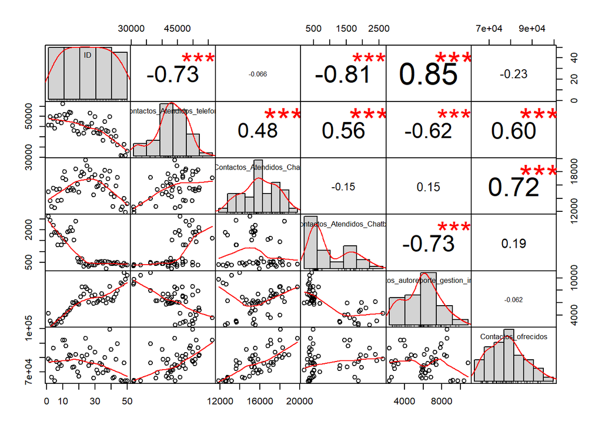

```r
df3 <- c()

df3 <- data.frame(df2.2)
borrar <- c("Mesa","Fecha")
df3 <- df3[ , !(names(df3) %in% borrar)]

library("PerformanceAnalytics")
df3.1 <- c()
df3.1 <- df3[,1:3]
chart.Correlation(df3[,1:6], histogram=TRUE, pch=19)
```

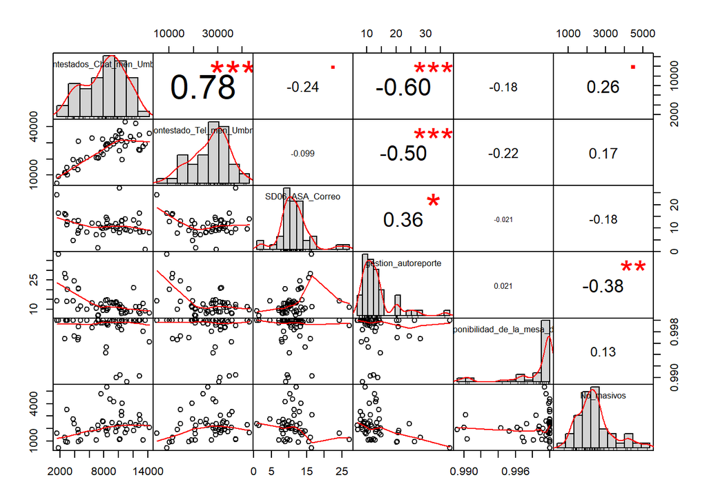

```r
chart.Correlation(df3[,7:12], histogram=TRUE, pch=19)
```

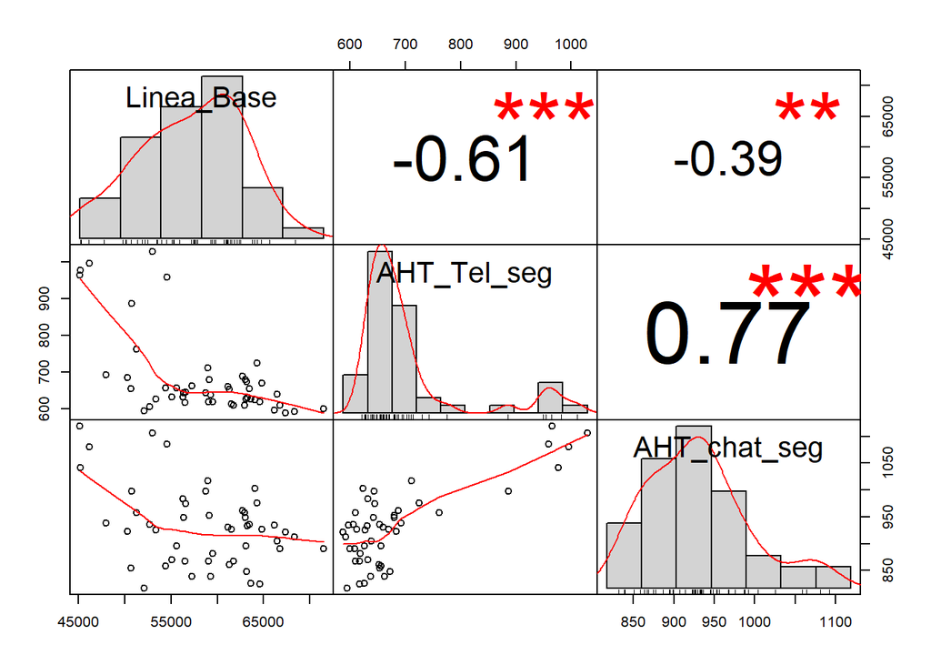

```r
chart.Correlation(df3[,13:15], histogram=TRUE, pch=19)
```

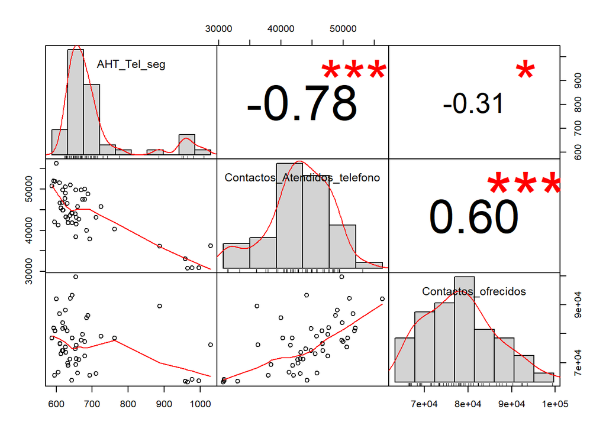

```r
#chart.Correlation(df3[,15:18], histogram=TRUE, pch=19)

relacion_AHT_Tel <- c("AHT_Tel_seg","Contactos_Atendidos_telefono","Contactos_ofrecidos")
chart.Correlation(df3[,relacion_AHT_Tel], histogram=TRUE, pch=19)
```